# Notebook 04 – Solutions

## Getting Started

Before running this notebook, select “Session > Restart R and Clear Output” in the menu above to start a new R session. This will clear any old data sets and give us a blank slate to start with.

After starting a new session, run the following code chunk to load the libraries and data that we will be working with today.

I have set the options `include=FALSE` and `message=FALSE` to avoid cluttering the solutions with all the output from this code.

# Practice

For practice, we will work again with the largest cities datasets:

```r
cities <- read_csv(file.path("data", "largest_cities.csv"))
```

We will also work with a second dataset of U.S. city populations over time. The code below, which we will learn about next time, will select three cities of data (Boston, Chicago, and LA) for us to work with:

```r
us_three <- read_csv(file.path("data", "us_city_population.csv")) %>%
  filter(city %in% c("Boston, MA", "Chicago, IL", "Los Angeles, CA"))
```

You may want to take a moment to look at this new dataset to understand what features are available.

## Color and Size

In this section we will use the `cities` dataset. In the code below, produce a scatter plot with longitude on the x-axis and latitude on the y-axis. Make the points scale with the size of the city’s population.

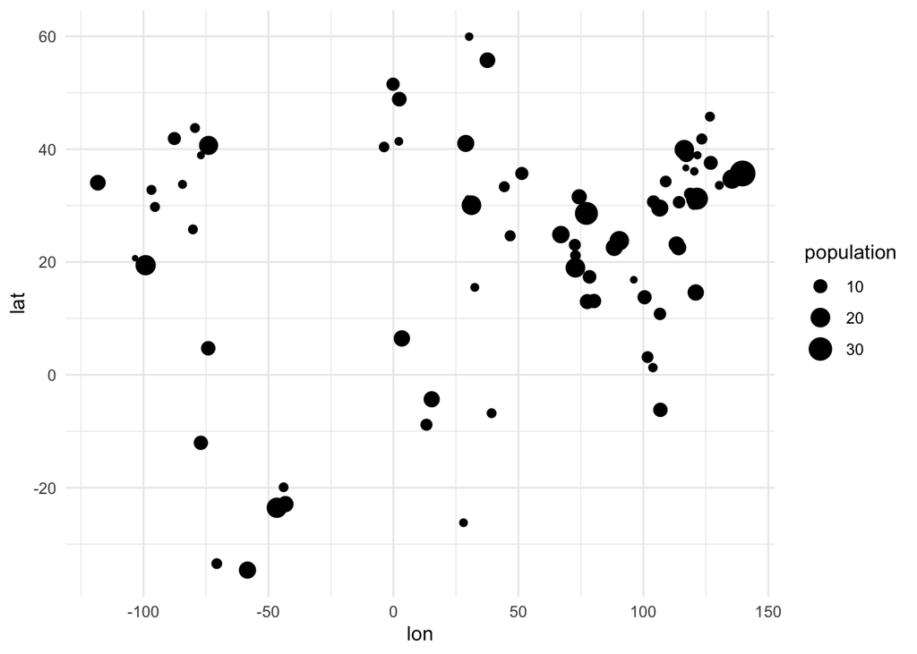

```r
cities %>%
  ggplot() +
    geom_point(aes(x = lon, y = lat, size = population))
```

What region(s) seem to have the highest concentration of large cities? **Answer**: Most of the largest cities are in Indian and China.

Below, repeat the same plot but now scale the color (not the size) of the points based on the population.

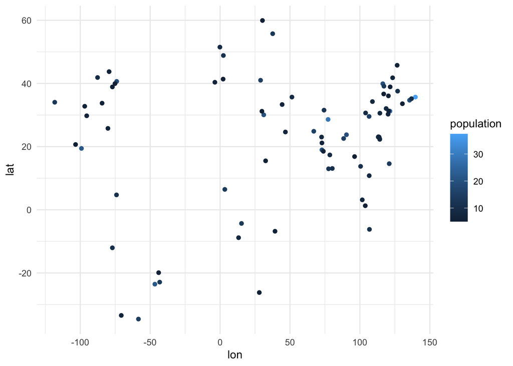

```r
cities %>%
  ggplot() +
    geom_point(aes(x = lon, y = lat, color = population))
```

Which of these two plots (color or size) do you find easier to read? Why? **Answer**: With the default scale, I find the size plot much easier to read because the default continuous scale is really quite bad.

In the code below, plot the cities data with the city longitude on the x-axis and latitude on the y-axis. Color the points based on the continent the city is in and make the size proportional to the population.

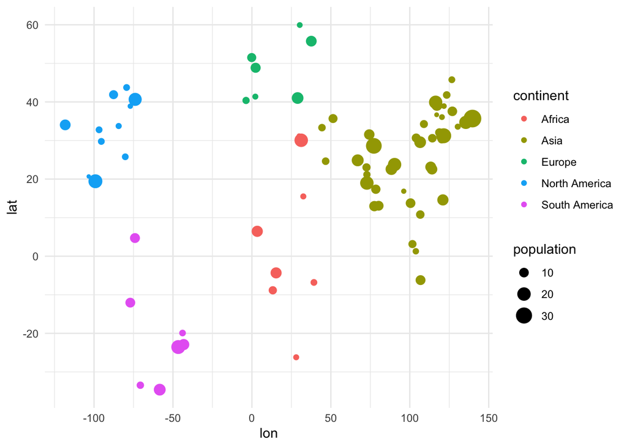

```r
cities %>%
  ggplot() +
    geom_point(aes(x = lon, y = lat, color = continent, size = population))
```

## Group Aesthetic

In this section, we will use the `us_three` dataset. In the code below we are going to produce a line plot with year on the x-axis and population on the y-axis. To do this, use the `geom_line` geometry.

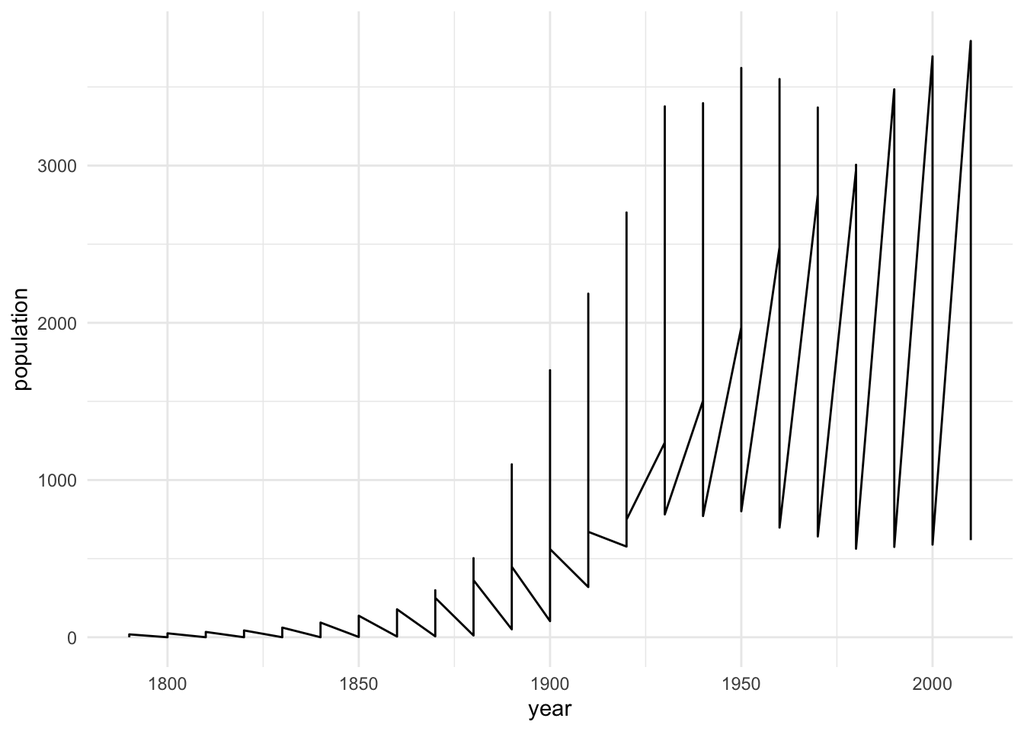

```r
us_three %>%
  ggplot() +
    geom_line(aes(x = year, y = population))
```

You should see a strange plot that seems to have a jagged, comb-like pattern to it. Below, repeat this plot but add a points layer that is colored by the city name (do not add color yet to the lines)

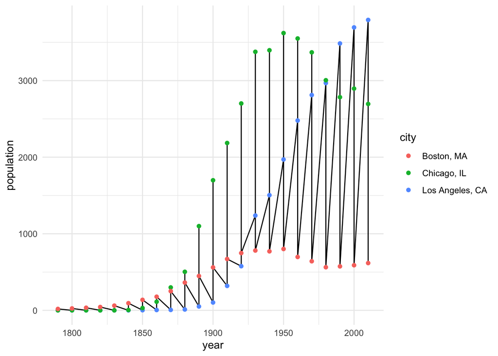

```r
us_three %>%
  ggplot() +
    geom_line(aes(x = year, y = population)) +
    geom_point(aes(x = year, y = population, color = city))
```

Can you see what’s happening now? The line plot is drawing a single line, from the smallest year to the largest year, without ever lifting up its pen. It is connecting across time and space, producing a plot that is nearly meaningless (or at least, very hard to interpret).

In the code below, produce a line plot with year on the x-axis and population on the y-axis. Color the lines by city. Do not include a points layer.

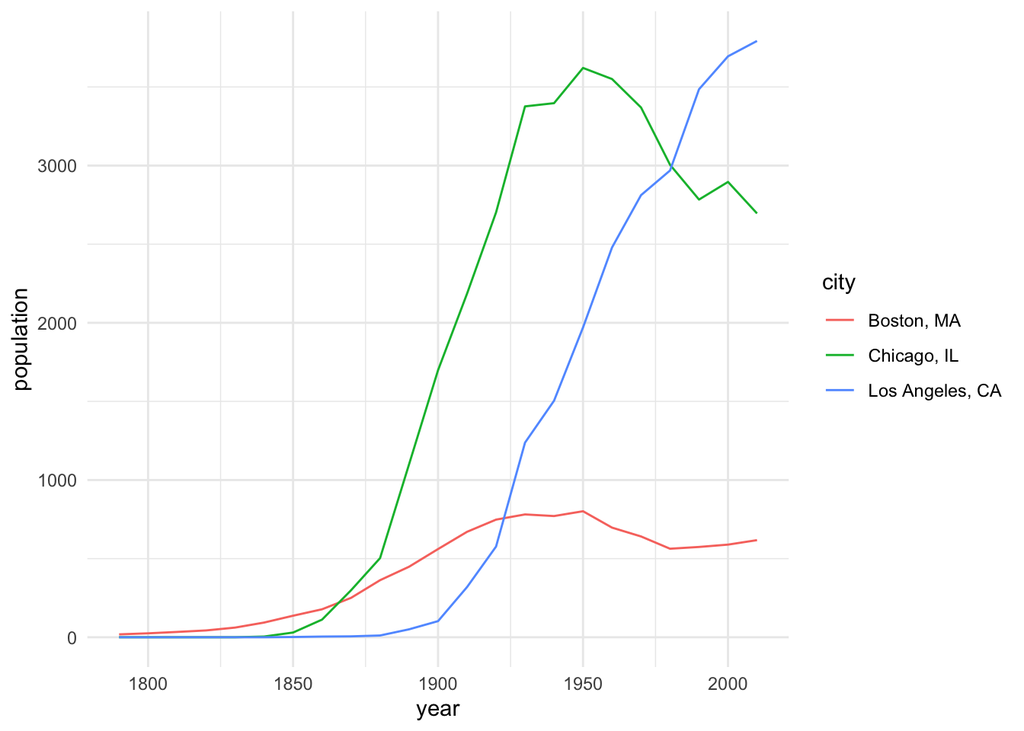

```r
us_three %>%
  ggplot() +
    geom_line(aes(x = year, y = population, color = city))
```

This plot should now look a lot nicer as it shows a different line for each city. To understand what is going on, produce the same plot in the code below, but replace the `color` aes with a new aes called `group`. In other words, map the `group` aesthetic to the city aesthetic.

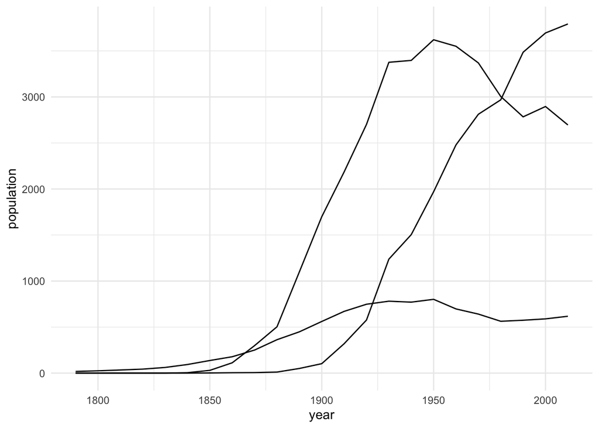

```r
us_three %>%
  ggplot() +
    geom_line(aes(x = year, y = population, group = city))
```

You should now see three lines that are all in black. It is this exact plot that was being colored in the previous example.

What’s going on here? When we add aesthetics such as color and size to a line geometry, another aesthetic called `group` is magically set at the same time. It is possible to set this aesthetic explicitly if we want to group the data without producing a different size or color.

## Fixed Aesthetics

Now, return again to the `cities` dataset. Produce a scatter plot with longitude and latitude, but color all of the points the color “pink”.

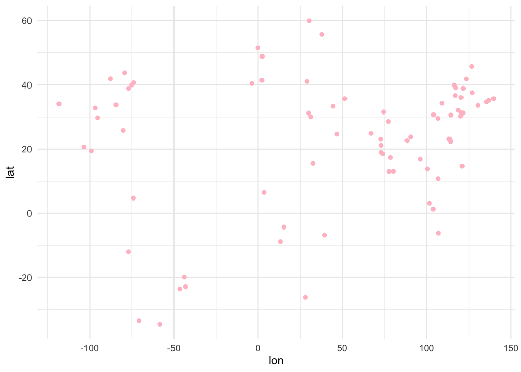

```r
cities %>%
  ggplot() +
    geom_point(aes(x = lon, y = lat), color = "pink")
```

Starting from the plot in the previous question, modify the size of the points to change with the population of each city.

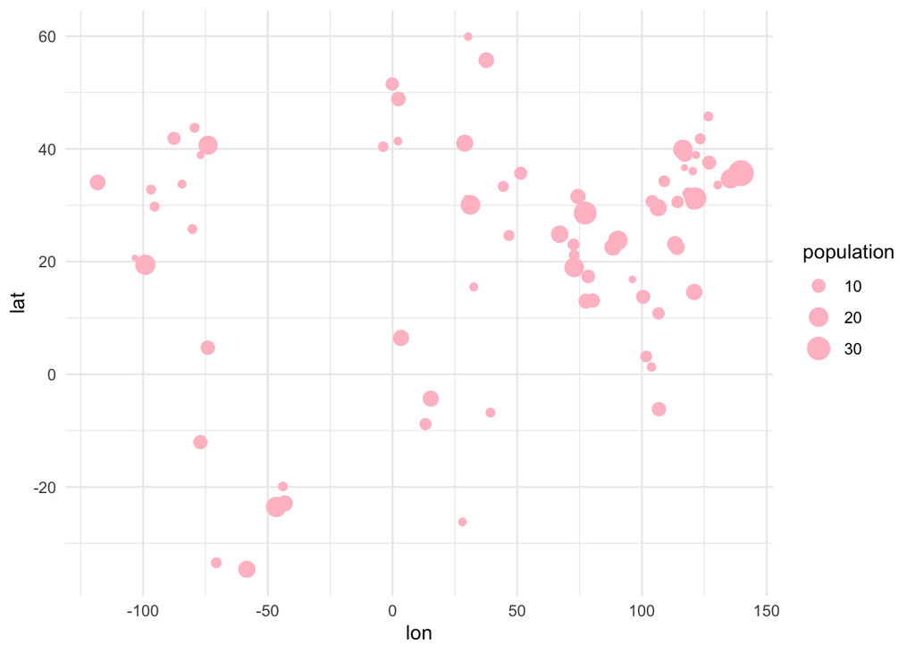

```r
cities %>%
  ggplot() +
    geom_point(aes(x = lon, y = lat, size = population), color = "pink")
```

Another aesthetic value that was not covered in the notes above is `alpha`. It is given by a number between 0 and 1 and sets how opaque the points are shown. Most typically it is used as a fixed aesthetic to make a plot with a large number of points more readable. Starting with the plot in the previous question, add a fixed aesthetic to change the alpha value of the points to 0.4.

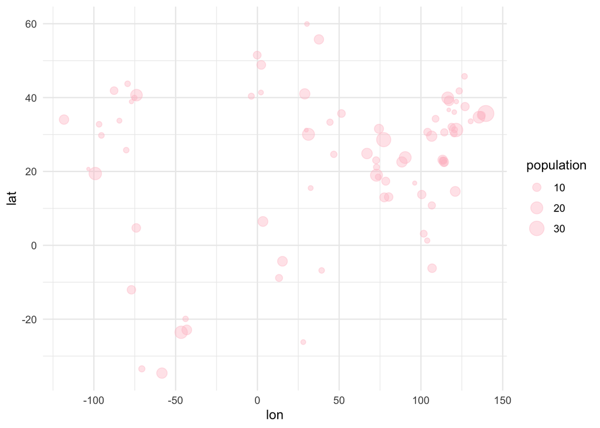

```r
cities %>%
  ggplot() +
    geom_point(
      aes(x = lon, y = lat, size = population),
      color = "pink",
      alpha = 0.4
    )
```

Notice how the areas where multiple cities overlap are darker than the surrounding regions.

## Scales

With the `cities` dataset, produce a scatter plot with city area (`city_area`) on the x-axis and city population (`city_pop`) on the y-axis.

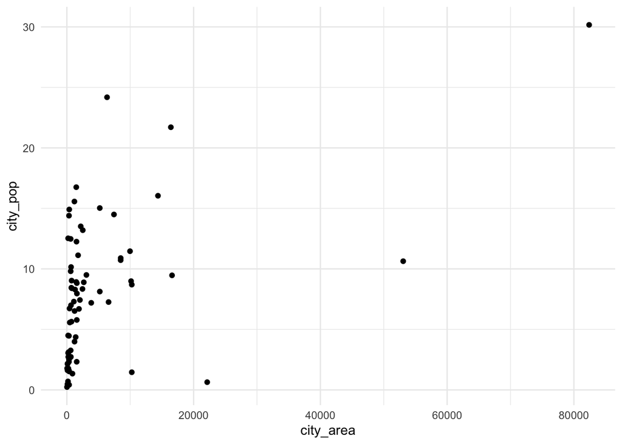

```r
cities %>%
  ggplot() +
    geom_point(aes(x = city_area, y = city_pop))
```

You should find that it is difficult to interpret this plot because most of the cities are squished together on the left-side of the plot. One way to fix this is to use a logarithmic scale. In the code block below, provide a modification of this plot with logarithmic scales for the x- and y-axes.

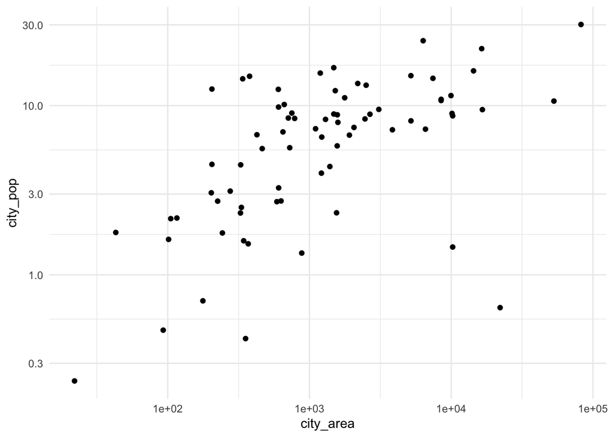

```r
cities %>%
  ggplot() +
    geom_point(aes(x = city_area, y = city_pop)) +
    scale_x_log10() +
    scale_y_log10()
```

You should find this plot easier to work with. If you are not familiar with the scientific notation used on the x-axis labels here, make sure to [learn more about these](https://en.wikipedia.org/wiki/Scientific_notation) as they will appear from time-to-time throughout the notes in this course.

## Color Scales

The Köppen climate classification is a way of describing the climate of a region or city. Information about these scores are included in the `cities` dataset and are something that we will explore in length in future notebooks. Here we will work with the four level categorization stored in the feature `koppen_main` (there are actually five levels, but the coldest level is not present in this dataset).

In the code block below, produce a scatter plot of the `cities` dataset with longitude on the x-axis and latitude on the y-axis. Color the points based on the `koppen_main` feature.

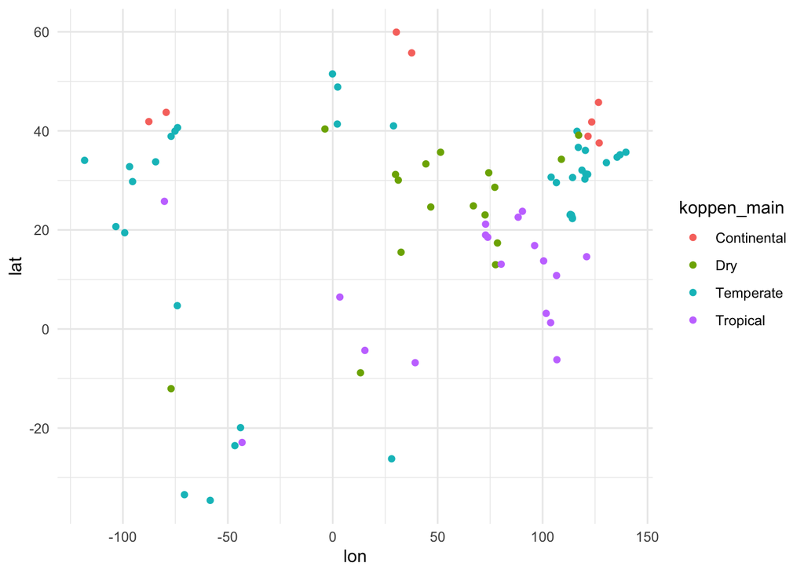

```r
cities %>%
  ggplot() +
    geom_point(aes(x = lon, y = lat, color = koppen_main))
```

In the code below, modify this plot to use the color-blind friendly Viridis color scale:

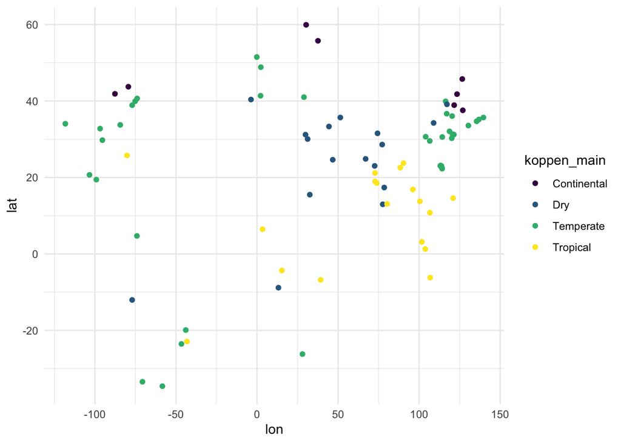

```r
cities %>%
  ggplot() +
    geom_point(aes(x = lon, y = lat, color = koppen_main)) +
    scale_color_viridis_d()
```

There is a well-known and standardized color scale for the Köppen codes. We will use the full palette in a future notebook; here we will just set values for the four main categories. In the code below repeat the scatterplot, but add a manual color scale where the “Tropical” climates are blue, the “Dry” climates are red, “Temperate” is green and “Continental” is purple.

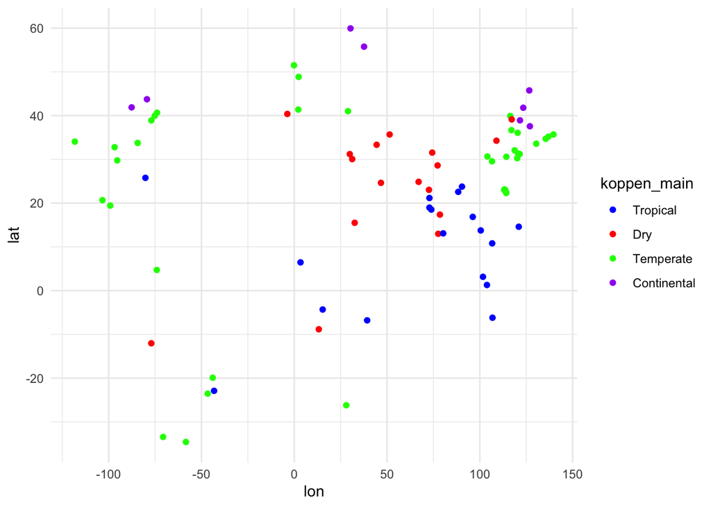

```r
cities %>%
  ggplot() +
    geom_point(aes(x = lon, y = lat, color = koppen_main)) +
    scale_color_manual(values = c(
      Tropical = "blue",
      Dry = "red",
      Temperate = "green",
      Continental = "purple"
    ))
```